# hw4 - ak

**Q1**

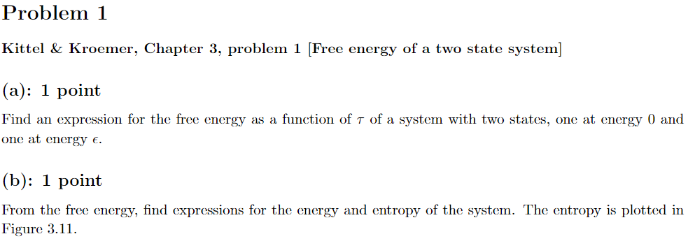

(a) Helmholtz free energy $F(\tau) = -\tau \ln Z$

$$ Z = e^{-0} + e^{-\epsilon/\tau} = 1 + e^{-\epsilon/\tau} \\ F(\tau) = -\tau \ln\left( 1+ e^{-\epsilon/\tau}\right) \\ $$ That was easy.

(b) Helmholtz free energy $F(\tau) = U - \tau \sigma$

$$ \sigma = - \frac{\partial F}{\partial \tau} = \ln\left(e^{-\epsilon/\tau}+1\right) + \frac{\epsilon}{\tau}\frac{ e^{-\epsilon/\tau}}{e^{-\epsilon/\tau}+1} $$

This makes finding the energy easy

$$ U(\tau) = F(\tau) + \tau \sigma \\ = -\tau \ln\left( 1+ e^{-\epsilon/\tau}\right) + \tau\ln\left(e^{-\epsilon/\tau}+1\right) + \epsilon\frac{ e^{-\epsilon/\tau}}{e^{-\epsilon/\tau}+1} \\ = \epsilon\frac{ e^{-\epsilon/\tau}}{1+e^{-\epsilon/\tau}} $$

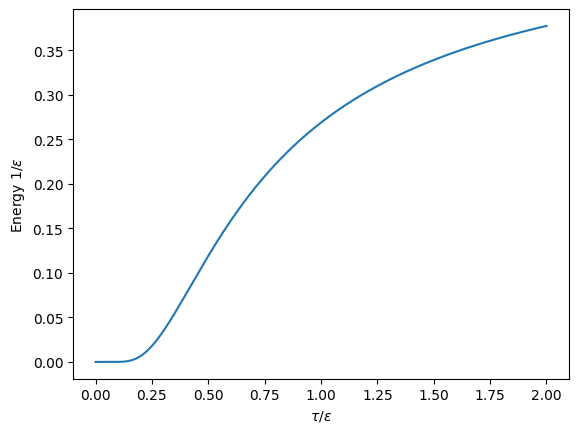

```python
import matplotlib.pyplot as plt
from numpy import exp, linspace

temp = linspace(0, 2, 1000)
energy = exp(-1/temp)/(1+exp(-1/temp))

plt.plot(temp, energy)
plt.xlabel(r'$\tau/\epsilon$')
plt.ylabel(r'Energy $1/\epsilon$')
```

**Q2**

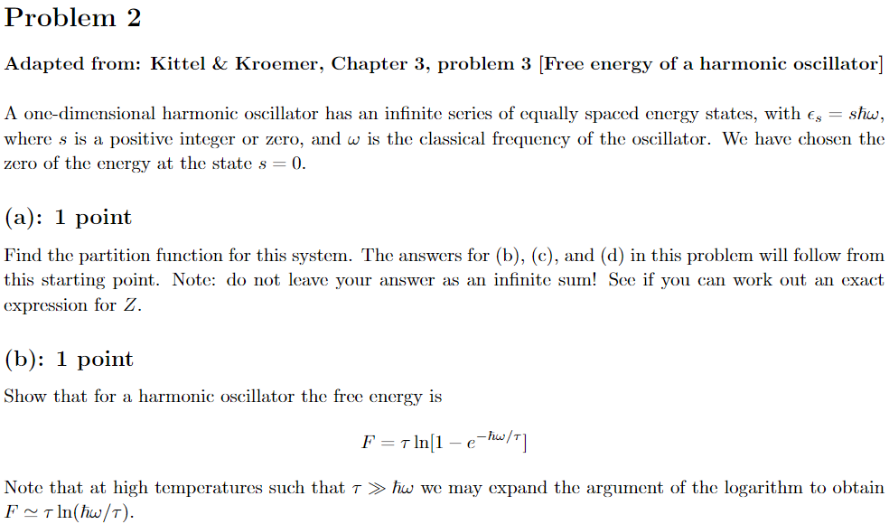

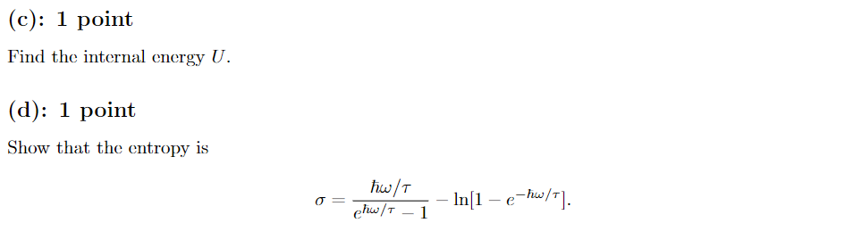

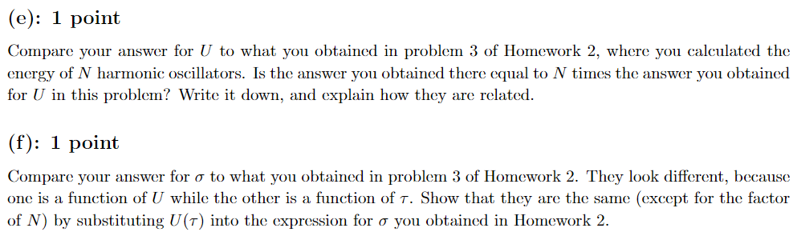

(a)

$$ Z = \sum_{s=0}^\infty e^{-\epsilon_s/\tau} = \sum_{s=0}^\infty e^{-s\hbar\omega/\tau} $$

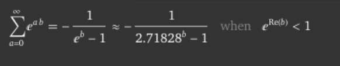

$$ Z = \frac{1}{1-e^{-\hbar \omega / \tau}} $$

(b) Easy! $F = -\tau \ln Z$

$$ F = -\tau \ln \left(\frac{1}{1-e^{-\hbar \omega / \tau}}\right) = \tau\ln \left(1-e^{\hbar \omega / \tau} \right) $$

(c) I'm actually going to skip this one and come back. I'd rather do the derivative of $\sigma$ than do this one.

Using $U = F + \tau \sigma$ we have

$$ U = \tau\ln \left(1-e^{\hbar \omega / \tau} \right) - \tau\ln \left(1-e^{\hbar \omega / \tau} \right) + \frac{\hbar \omega}{e^{\hbar \omega / \tau} -1} \\ = \frac{\hbar \omega}{e^{\hbar \omega / \tau} -1} $$ See derivation of $\sigma$ below

(d) Here we'll take the derivative of $F$

$\sigma = \frac{\partial F}{\partial \tau} $

```python
from sympy import symbols, ln, exp, diff, latex, Derivative

hbar, omega, tau = symbols('hbar omega tau')

print('Helmholtz energy:')
F = tau*ln(1-exp(-hbar*omega/tau))
display(F)

sigma = - diff(F, tau)
print('Entropy:')
sigma
```

```
Helmholtz energy:
```

$\displaystyle \tau \log{\left(1 - e^{- \frac{\hbar \omega}{\tau}} \right)}$

```
Entropy:
```

$\displaystyle \frac{\hbar \omega e^{- \frac{\hbar \omega}{\tau}}}{\tau \left(1 - e^{- \frac{\hbar \omega}{\tau}}\right)} - \log{\left(1 - e^{- \frac{\hbar \omega}{\tau}} \right)}$

This works out to be exactly what we're looking for:

$$ \frac{\hbar \omega e^{- \frac{\hbar \omega}{\tau}}}{\tau \left(1 - e^{- \frac{\hbar \omega}{\tau}}\right)} \cdot \frac{e^{\hbar \omega / \tau}}{e^{\hbar \omega / \tau}} = \frac{\hbar \omega/\tau}{e^{\hbar \omega/\tau}-1} $$

$$ \sigma = \frac{\hbar \omega e^{- \frac{\hbar \omega}{\tau}}}{\tau \left(1 - e^{- \frac{\hbar \omega}{\tau}}\right)} - \ln{\left(1 - e^{- \frac{\hbar \omega}{\tau}} \right)} \\ = \frac{\hbar \omega/\tau}{e^{\hbar \omega/\tau}-1} - \ln{\left(1 - e^{- \frac{\hbar \omega}{\tau}} \right)} $$

(e) HW2P3: $U = \frac{N\hbar \omega}{e^{\hbar \omega/\tau}-1}$

Yes, it is $N$ times my result. This makes sense since it is $N$ oscillators, where this question asks about a single oscillator.

(f)

HW2P3:

I'll use the result from the answer key

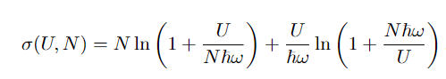

Let's insert in $U(\tau)$

$$ \sigma(\tau, N) = N \ln \left(1+\frac{\frac{N\hbar \omega}{e^{\hbar \omega/\tau}-1}}{N\hbar \omega} \right) + \frac{\frac{N\hbar \omega}{e^{\hbar \omega/\tau}-1}}{\hbar \omega} \ln \left( 1 + \frac{N\hbar\omega}{\frac{N\hbar \omega}{e^{\hbar \omega/\tau}-1}}\right) $$

$$ = N \ln \left(1+\frac{1}{e^{\hbar \omega/\tau}-1} \right) + \frac{N}{e^{\hbar \omega/\tau}-1}\ln \left( 1 + e^{\hbar \omega/\tau}-1\right) $$

$$ = N \ln \left(1+\frac{1}{e^{\hbar \omega/\tau}-1} \right) + \frac{N \hbar \omega /\tau}{e^{\hbar \omega/\tau}-1} \\ = N \ln \left(\frac{e^{\hbar \omega/\tau}}{e^{\hbar \omega/\tau}-1} \right) + \frac{N \hbar \omega /\tau}{e^{\hbar \omega/\tau}-1} \\ = -N \ln \left(\frac{e^{\hbar \omega/\tau}-1}{e^{\hbar \omega/\tau}} \right) + \frac{N \hbar \omega /\tau}{e^{\hbar \omega/\tau}-1} \\ =N \left(\frac{\hbar \omega/\tau}{e^{\hbar \omega/\tau}-1} - \ln{\left(1 - e^{- \frac{\hbar \omega}{\tau}} \right)} \right) $$

Yippie! Entropy is also just multiplied by $N$ since each oscillator isn't interacting and entropy adds like energy

**Q3**

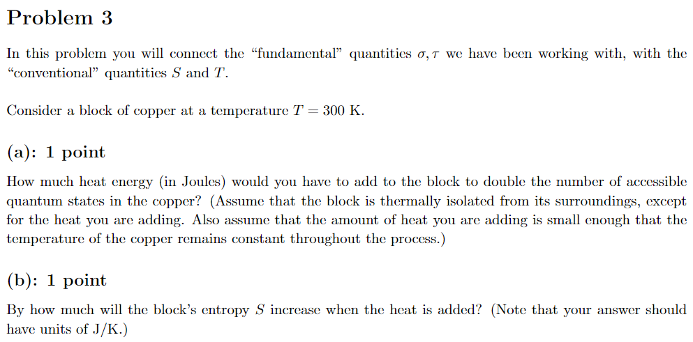

(a) Adding energy -> $U$ goes up.

$$ F = U - \tau \sigma \\ \Delta F = \Delta U - \tau \Delta \sigma $$

The system does no work, so $\Delta F = 0$ $$ \Delta U = \tau \Delta \sigma \\ U =k_B T (\ln g) \\ $$

Going from $g_0$ to $2g_0$ states:

$$ U_f - U_i = k_B T (\ln 2g_0) - k_B T (\ln(g_0)) \\ \Delta U = k_B T \ln 2 = 2.87 \times 10^{-21} $$

```python
from scipy.constants import k
U = k*300*ln(2)
U.evalf()
```

$\displaystyle 2.87097888507872 \cdot 10^{-21}$

(b) $\Delta U/\tau = \Delta \sigma$

$$ S = k_b \sigma = k_b \frac{U}{k_b T} = \frac{U}{T} \\ S = 9.57 \times 10^{-24} $$

```python
S = U/300
S.evalf()
```

$\displaystyle 9.56992961692908 \cdot 10^{-24}$

**Q4**

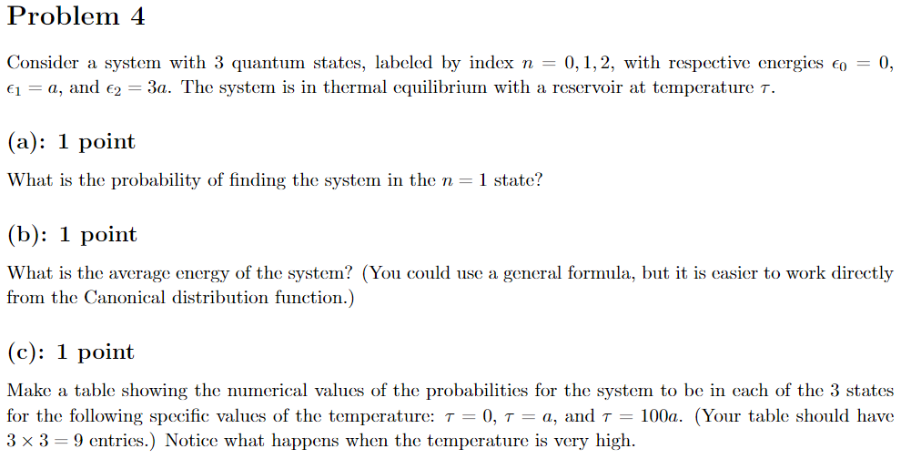

(a) We can find probabilities using $Z$

$$ Z = 1 + e^{-a/\tau} + e^{-3a/\tau} \\ P(1) = \frac{e^{-a/\tau}}{1 + e^{-a/\tau} + e^{-3a/\tau}} $$

(b) Using a summation:

$$ U = 0+aP(1) + 3a P(2) = \frac{ae^{-a/\tau}+3ae^{-3a/\tau}}{1 + e^{-a/\tau} + e^{-3a/\tau}} $$

(c)

|  | P(0) | P(1) | P(2) |
| --- | --- | --- | --- |
| $\tau$ = 0 | 1 | 0 | 0 |
| $\tau$ = a | 0.7 | 0.26 | 0.04 |
| $\tau$ = 100a | .34 | .33 | .33 |

high temp: all energies are equally likely

```python
a = symbols('a')

e0 = 1
e1 = exp(-a/tau)
e2 = exp(-3*a/tau)

Z = e0 + e1 + e2
(e0/Z).replace(tau,a*100).evalf()
```

$\displaystyle 0.337781308846565$

**Q5**

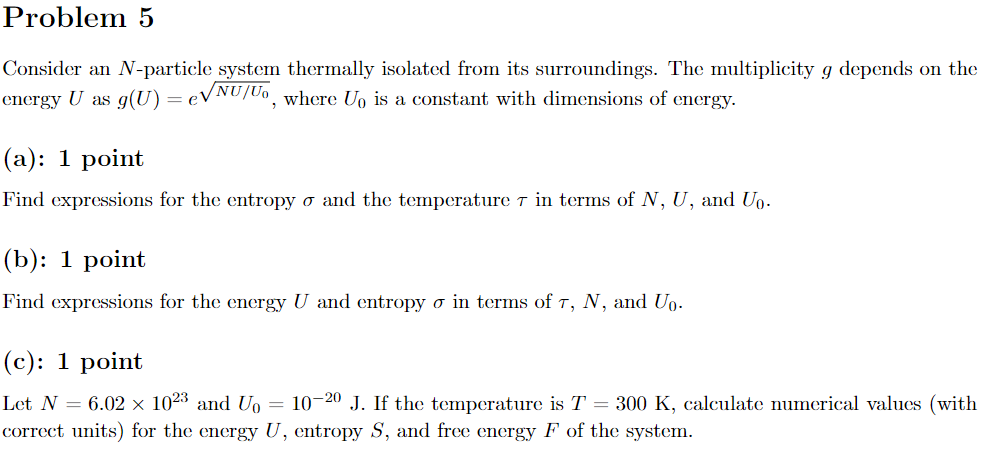

Return to microcanonical

(a) $\sigma(U) = \ln(g(U))$ easy

$\sigma(U) = \ln \left(e^{\sqrt{NU/U_0}} \right) = \sqrt{NU/U_0}$

(b) $1/\tau = d\sigma/dU$

$$ \frac{1}{\tau} = \frac{\partial}{\partial U} \sqrt{\frac{N}{U_0}}\sqrt{U} \\ = \sqrt{\frac{N}{U_0}} \frac{\partial}{\partial U}\sqrt{U} = \frac{1}{2}\sqrt{\frac{N}{U U_0}} \\ U(\tau) = \frac{N \tau^2}{4U_0} $$

(c)

Note that conventional $T$ and $S$ have different formulas

$$ \tau = k_B T \\ \sigma = \frac{S}{k_B} \\ $$ $\tau$ has units of energy, and $N$ is unitless $$ \tau = 4.14\times 10^{-21} J\\ U(\tau) = 258.19 J\\ S(U) = 1.7 J/K \\ F = U - \tau \sigma = -258.19 J $$

Interesting how $F=-U$

```python
from scipy.constants import k

tau = k*300
print(f'tau={tau} J')
N = 6.02e23
U0 = 1e-20

U = N*tau**2/(4*U0)
print(f'U={U:.2f} J')

sigma = (N*U/U0)**(1/2)
S = k*sigma
print(f'Entropy ={S} J/K')

F = U - tau * sigma
print(f'Helmholtz free energy={F:.3f} J')
```

```
tau=4.141947e-21 J
U=258.19 J
Entropy =1.7212910700645034 J/K
Helmholtz free energy=-258.194 J
```

If $\sigma \tau$ has units joules, then $\sigma$ must be unitless (boltzmann constant J/K)